# The Ridge Regression

Yingnan Lyu

2018-10-12

## The ridge_reg function

This vignette uses ridge_reg function and looks at effect on the out-of-sample mean square error in the ridge regression as $\lambda$ varies.

First, define a function that calculate out-of-sample mean squared error.

```r
library(bis557)

# A function to calculate MSE for ridge regression
ridge_mse <- function(formula, lambda, data.train, data.test) {

  # Calculate beta from trainning data
  fit_ridge <- ridge_reg(formula, lambda, data.train)
  beta <- fit_ridge$coef

  # Calculate y_hat from testing data
  x_test <- model.matrix(formula, ridge_test)
  y_test <- matrix(data.test[,as.character(formula)[2]], ncol=1)
  y_test <- y_test[as.numeric(rownames(x_test)),, drop=FALSE]
  #y_hat <- tcrossprod(x_test, beta)
  y_hat <- x_test %*% beta

  # Calculate out-of-sample MSE
  mse <- mean((y_hat - y_test)^2)
}
```

Then reasonable values can be inferred from the range of the singular values of the training data as shown in Equation 3.29 in the book. The $\lambda$ values are chosen based on the log scale.

```r
data("ridge_train")
data("ridge_test")

# Choose lambda range
X <- model.matrix(y ~ . - 1, ridge_train)
svdx <- svd(X)
d <- 1/svdx$d
range <- c(min(d), max(d))
log.range <- ceiling(log(range, base = 10))
log.lambdas.range <- log.range + c(-2, 2)
log.lambdas.range
```

```
## [1] -3  2
```

The range of $\lambda$ at log scale is found to be from -3 to 2.

Next, a sequence of $\lambda$ values are defined based the $\lambda$ range found. And out-of-sample MSE for each of the $\lambda$ value is calculated and plotted against log($\lambda$). Out-of-sample MSE decrease with the log($\lambda$) first and then gradually increase.

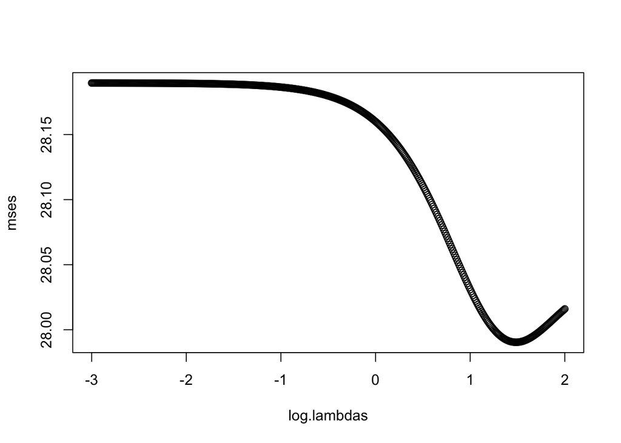

```r
# Define lambdas over the range
log.lambdas <- seq(log.lambdas.range[1], log.lambdas.range[2], by = 0.01)
lambdas <- 10^log.lambdas

# Calculate MSE for each lambda
mses <- sapply(lambdas,
               function(lambda)
                 ridge_mse(y ~ . - 1, lambda, ridge_train, ridge_test))

# Plot MSE against each log(lambda) value
plot(log.lambdas, mses)
```

```r
# Find lambda that minimize MSE
min.log.lambda <- log.lambdas[which.min(mses)]
min.log.lambda
```

```
## [1] 1.48
```

```r
min.lambda <- lambdas[which.min(mses)]
min.lambda
```

```
## [1] 30.19952
```

The out-of-sample MSE is minimized at log($\lambda$) = 1.48 or $lambda$ = 30.20.

To find a more accurate $\lambda$, we zoom in log($\lambda$) to a smaller range, which is log($\lambda$)-0.5 to log($\lambda$)+0.5. Then out-of-sample MSEs are calculated again using the new log($\lambda$) range.

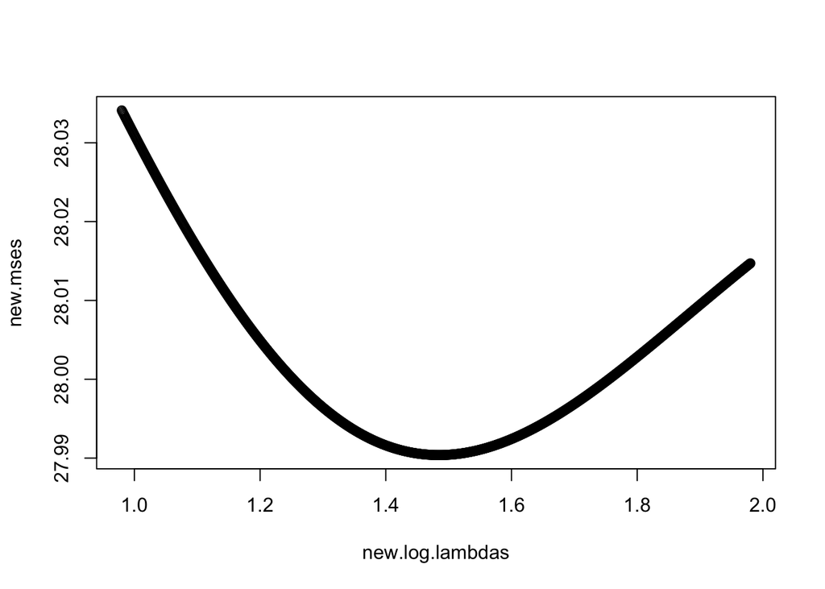

```r
# Zoom in lambda
new.log.lambdas <- seq(min.log.lambda - 0.5, min.log.lambda + 0.5, 0.001)
new.lambdas <- 10^new.log.lambdas

# Calculate MSE for each lambda
new.mses <- sapply(new.lambdas,
               function(lambda)
                 ridge_mse(y ~ . - 1, lambda, ridge_train, ridge_test))

# Plot MSE against each log(lambda) value
plot(new.log.lambdas, new.mses)
```

```r
# Find lambda that minimize MSE
min.new.log.lambda <- new.log.lambdas[which.min(new.mses)]
min.new.log.lambda
```

```
## [1] 1.484
```

```r
min.new.lambda <- new.lambdas[which.min(new.mses)]
min.new.lambda
```

```
## [1] 30.47895
```

Now the out-of-sample MSE is minimized at log($\lambda$) = 1.484 or $lambda$ = 30.479.